# Model characteristics analysis using Generalized Linear Mixed Models (GLMMs)

**Overview**

This notebook will guide you through the code to fit generalized linear mixed models to the data per crop and extreme type analyzing the effects of model characteristics on the odds of underestimating crop losses. The analysis is done in R. The following figures will be computed:

- Figure 5: faceted forest plot showing per crop and extreme the resulting 90% confidence intervals of the odds ratios for each model characteristic inferred from the GLMMs
- Supplementary figure 39: forest plot showing the 90% confidence intervals of the odds for the intercepts of the GLMMs for each combination of crop and extreme type.

The fully processed and filtered data files, available under GGCMI-validation/data/processed/figure_ready_data are required to produce the figures.

We load the libraries

```r
library(tidyverse) # Includes dplyr, ggplot2, readr, etc.
library(lme4) # for fitting GLMMs
library(broom.mixed) # to summarise model fits
library(sjPlot) # to set and configure plotting theme
library(spdep) # for spatial functions
library(tibble)  # to create model feature table
```

We set the theme

```r
theme_Scherer <- function (base_size = 12, base_family = "Helvetica") {
  half_line <- base_size/2
  theme(
    line = element_line(color = "black", linewidth = .5,
                        linetype = 1, lineend = "butt"),
    rect = element_rect(fill = "white", color = "black",
                        linewidth = .5, linetype = 1),
    text = element_text(family = base_family, face = "plain",
                        color = "black", size = base_size,
                        lineheight = .9, hjust = .5, vjust = .5,
                        angle = 0, margin = margin(), debug = FALSE),
    axis.line = element_blank(),
    axis.line.x = NULL,
    axis.line.y = NULL,
    axis.text = element_text(size = base_size * 1.1, color = "gray30"),
    axis.text.x = element_text(margin = margin(t = .8 * half_line/2),
                               vjust = 1),
    axis.text.x.top = element_text(margin = margin(b = .8 * half_line/2),
                                   vjust = 0),
    axis.text.y = element_text(margin = margin(r = .8 * half_line/2),
                               hjust = 1),
    axis.text.y.right = element_text(margin = margin(l = .8 * half_line/2),
                                     hjust = 0),
    axis.ticks = element_line(color = "gray30", linewidth = .7),
    axis.ticks.length = unit(half_line / 1.5, "pt"),
    axis.ticks.length.x = NULL,
    axis.ticks.length.x.top = NULL,
    axis.ticks.length.x.bottom = NULL,
    axis.ticks.length.y = NULL,
    axis.ticks.length.y.left = NULL,
    axis.ticks.length.y.right = NULL,
    axis.title.x = element_text(margin = margin(t = half_line),
                                vjust = 1, size = base_size * 1.3,
                                face = "bold"),
    axis.title.x.top = element_text(margin = margin(b = half_line),
                                    vjust = 0),
    axis.title.y = element_text(angle = 90, vjust = 1,
                                margin = margin(r = half_line),
                                size = base_size * 1.3, face = "bold"),
    axis.title.y.right = element_text(angle = -90, vjust = 0,
                                      margin = margin(l = half_line)),
    legend.background = element_rect(color = NA),
    legend.spacing = unit(.4, "cm"),
    legend.spacing.x = NULL,
    legend.spacing.y = NULL,
    legend.margin = margin(.2, .2, .2, .2, "cm"),
    legend.key = element_rect(fill = "gray95", color = "white"),
    legend.key.size = unit(1.2, "lines"),
    legend.key.height = NULL,
    legend.key.width = NULL,
    legend.text = element_text(size = rel(.8)),
    legend.text.align = NULL,
    legend.title = element_text(hjust = 0),
    legend.title.align = NULL,
    legend.position = "right",
    legend.direction = NULL,
    legend.justification = "center",
    legend.box = NULL,
    legend.box.margin = margin(0, 0, 0, 0, "cm"),
    legend.box.background = element_blank(),
    legend.box.spacing = unit(.4, "cm"),
    panel.background = element_rect(fill = "white", color = NA),
    panel.border = element_rect(color = "gray30",
                                fill = NA, linewidth = .7),
    panel.grid.major = element_line(color = "gray90", linewidth = 1),
    panel.grid.minor = element_line(color = "gray90", linewidth = .5,
                                    linetype = "dashed"),
    panel.spacing = unit(base_size, "pt"),
    panel.spacing.x = NULL,
    panel.spacing.y = NULL,
    panel.ontop = FALSE,
    strip.background = element_rect(fill = "white", color = "gray30"),
    strip.text = element_text(color = "black", size = base_size),
    strip.text.x = element_text(margin = margin(t = half_line,
                                                b = half_line)),
    strip.text.y = element_text(angle = -90,
                                margin = margin(l = half_line,
                                                r = half_line)),
    strip.text.y.left = element_text(angle = 90),
    strip.placement = "inside",
    strip.placement.x = NULL,
    strip.placement.y = NULL,
    strip.switch.pad.grid = unit(0.1, "cm"),
    strip.switch.pad.wrap = unit(0.1, "cm"),
    plot.background = element_rect(color = NA),
    plot.title = element_text(size = base_size * 1.8, hjust = .5,
                              vjust = 1, face = "bold",
                              margin = margin(b = half_line * 1.2)),
    plot.title.position = "panel",
    plot.subtitle = element_text(size = base_size * 1.3,
                                 hjust = .5, vjust = 1,
                                 margin = margin(b = half_line * .9)),
    plot.caption = element_text(size = rel(0.9), hjust = 1, vjust = 1,
                                margin = margin(t = half_line * .9)),
    plot.caption.position = "panel",
    plot.tag = element_text(size = rel(1.2), hjust = .5, vjust = .5),
    plot.tag.position = "topleft",
    plot.margin = margin(rep(base_size, 4)),
    complete = TRUE
  )
}
set_theme(theme_Scherer())
```

Loading the data

```r
base_path <- "C:/Users/kobed/Documents/TOAD-PIKlegacy" # Where is the code repo stored?

# List of crops
crops <- c("mai", "wwh", "ri1", "soy")

# Read each .rds file into a named list
crop_data <- lapply(crops, function(crop) {
  readRDS(file.path(base_path, paste0("extremes_", crop, ".rds")))
})
names(crop_data) <- crops
```

## Fitting the GLMM

we first have to prepare the data by creating a binary variable indicating whether underestimation takes place or not and by creating binary characteristics variables, indicating if the model simulating the observation has the corresponding characteristic or not. We also create a variable for each lat-llon combination (grid cell, location ID).

```r
data_GLMM_list <- list()

for (crop in crops) {
  data_GLMM_list[[crop]] <- crop_data[[crop]] %>%
    filter(crop == !!crop, model != "ensemble") %>% #exclude model ensemble
    mutate(
        # Underestimation or not?
      under_pred = as.integer(difftrend_sim > difftrend_obs),

        # Binary variables for model characteristics
      soilCN = ifelse(model %in% c("dssat-pythia", "epic-iiasa", "isam", "ldndc", "lpj-guess", "lpjml", "pepic", "simplace-lintul5", "pdssat"), 1, 0),
      waterlogging = ifelse(model %in% c("dssat-pythia", "epic-iiasa", "pepic", "acea", "cygma1p74"), 1, 0),
      photosynthesis = ifelse(model %in% c("crover", "isam", "ldndc", "lpj-guess", "lpjml", "promet", "pdssat"), 1, 0),
      complexTstress = ifelse(model %in% c("acea", "isam", "promet", "pdssat"), 1, 0),
      varroots = ifelse(model %in% c("acea", "dssat-pythia", "epic-iiasa", "isam", "pepic", "promet", "simplace-lintul5", "pdssat"), 1, 0),
      dynamicHI = ifelse(model %in% c("acea", "dssat-pythia", "epic-iiasa", "isam", "pepic", "promet", "simplace-lintul5", "pdssat", "ldndc", "lpj-guess", "cygma1p74"), 1, 0),

      model = as.factor(model)
    ) %>%
    group_by(lon, lat) %>%
    # Add a gridcell_ID for each lon-lat combination
    mutate(gridcell_id = cur_group_id()) %>%
    ungroup() %>%
    dplyr::select(gridcell_id, model, lon, lat, year, dynamicHI, varroots, complexTstress, photosynthesis, waterlogging, soilCN, under_pred, climate_extreme)
}
```

Here, we list the 6 different model characteristics with their abbreviations that we will use throughout the analysis and figure.

- **soilCN**: models that incorporate carbon and nitrogen dynamics in the soil
- **waterlogging**: models that account for waterlogging effects (too much water)
- **photosynthesi**s: models that have dynamic/explicit photosynthesis rather than a fixed radiative use efficiency (RUE)
- **varroots**: models that model the crop roots in function of temperature and/or water
- **dynamicHI**: models with a dynamic harvest index (depending on external stresses) instead of a fixed harvest index
- **complexTstress**: models with a more complex implementation of temperature stress

Let’s create a quick table listing which model has which features. A more detailed table and information on the characteristics can be found in the supplementary information of the paper.

```r
# List of all models
models <- c("acea", "crover", "cygma1p74", "dssat-pythia", "epic-iiasa", "isam",
            "ldndc", "lpj-guess", "lpjml", "pepic", "promet", "simplace-lintul5", "pdssat")

# Create table with binary indicators
model_features <- tibble(model = models) %>%
  mutate(
    soilCN = ifelse(model %in% c("dssat-pythia", "epic-iiasa", "isam", "ldndc", "lpj-guess", "lpjml", "pepic", "simplace-lintul5", "pdssat"), 1, 0),
    waterlogging = ifelse(model %in% c("dssat-pythia", "epic-iiasa", "pepic", "acea", "cygma1p74"), 1, 0),
    photosynthesis = ifelse(model %in% c("crover", "isam", "ldndc", "lpj-guess", "lpjml", "promet", "pdssat"), 1, 0),
    complexTstress = ifelse(model %in% c("acea", "isam", "promet", "pdssat"), 1, 0),
    varroots = ifelse(model %in% c("acea", "dssat-pythia", "epic-iiasa", "isam", "pepic", "promet", "simplace-lintul5", "pdssat"), 1, 0),
    dynamicHI = ifelse(model %in% c("acea", "dssat-pythia", "epic-iiasa", "isam", "pepic", "promet", "simplace-lintul5", "pdssat", "ldndc", "lpj-guess", "cygma1p74"), 1, 0)
  )

# View the table
print(model_features)
```

```
# A tibble: 13 × 7
   model    soilCN waterlogging photosynthesis complexTstress varroots dynamicHI
   <chr>     <dbl>        <dbl>          <dbl>          <dbl>    <dbl>     <dbl>
 1 acea          0            1              0              1        1         1
 2 crover        0            0              1              0        0         0
 3 cygma1p…      0            1              0              0        0         1
 4 dssat-p…      1            1              0              0        1         1
 5 epic-ii…      1            1              0              0        1         1
 6 isam          1            0              1              1        1         1
 7 ldndc         1            0              1              0        0         1
 8 lpj-gue…      1            0              1              0        0         1
 9 lpjml         1            0              1              0        0         0
10 pepic         1            1              0              0        1         1
11 promet        0            0              1              1        1         1
12 simplac…      1            0              0              0        1         1
13 pdssat        1            0              1              1        1         1
```

Then we define the Generalized Linear Mixed-Effects Model (GLMM) with a binomial distribution (logistic link) to estimate the binary outcome of underestimation or not. Note that we define the fixed effects of the model based on the extreme type, so waterlogging we only test under wet extremes, while complex temperature stress only under dry and hot conditions. This is to avoid complete separation in the fit and avoid redundant results. Note that some crops are not simulated by all 13 models, which makes it tricky to include all characteristics for fewer models without complete separation. The random effects remain for each GLMM the same, including a spatial (gridcell_id), temporal (year) and model factor. These are essential to infer the results of the GLMM and to be able to make statements about a “larger population” avoiding overconfident results for the fixed effects as the random effects account for additional variations between locations, years and models that cannot be captured by the fixed effects alone. This is a common practice in hierarchical datasets such as ours and also prevents us from violating the assumption of independence: observations from the same grid cell or same year or same model are not really independent and we have to inform our GLMM about this to avoid overconfident effects.

```r
run_GLMM <- function(data_model, extreme) {

     # Define random effects (always included)
  random_effects <- "(1|gridcell_id) + (1|year) + (1|model)"

  # Define fixed effects based on extreme type
  fixed_effects <- switch(extreme,
    "Dry" = "dynamicHI + varroots + photosynthesis + soilCN + complexTstress",
    "Wet" = "dynamicHI + varroots + photosynthesis + soilCN + waterlogging",
    "Hot" = "dynamicHI + varroots + photosynthesis + soilCN + complexTstress",
    stop("Unknown extreme: must be one of 'Dry', 'Wet', or 'Hot'")
  )

  # Combine into full formula
  model_formula <- as.formula(
    paste("under_pred ~", fixed_effects, "+", random_effects)
  )

  # Fit and return the model
  glmer(model_formula, data = data_model, family = binomial())
}
```

Then we are set to fit the model for each combination of crop and extreme type. We provide for each of the twelve models a statistical summary of the fit and results in terms of odds (ratios), i.e. exponentiated log-odds.

```r
# Define climate extremes
extremes = c("Dry", "Hot", "Wet")

# Define a list to store the GLMMs
GLMM_results <- list()

# Loop over crops and extremes
for (crop in crops) { # start the crops loop
    cat("Processing:", crop, "\n")

    for (extreme in extremes){ # start extremes loop
        cat("Processing:", extreme, "\n")

        data_GLMM = data_GLMM_list[[crop]] %>%
        filter(climate_extreme == extreme)

        model <- run_GLMM(data_GLMM, extreme)
        GLMM_results[[paste(crop, extreme, sep = "_")]] <- model

        print(broom.mixed::tidy(model, exponentiate = TRUE, conf.int = TRUE)) # statistical summary

    } # end of the extremes loop
} # end of the crops loop
```

```
Processing: mai
Processing: Dry
# A tibble: 9 × 9
  effect   group   term  estimate std.error statistic p.value conf.low conf.high
  <chr>    <chr>   <chr>    <dbl>     <dbl>     <dbl>   <dbl>    <dbl>     <dbl>
1 fixed    <NA>    (Int…    4.44      2.81      2.36   0.0185    1.28      15.3
2 fixed    <NA>    dyna…    0.518     0.298    -1.14   0.253     0.168      1.60
3 fixed    <NA>    varr…    1.16      0.781     0.220  0.826     0.310      4.34
4 fixed    <NA>    phot…    2.05      1.26      1.18   0.240     0.618      6.82
5 fixed    <NA>    soil…    0.471     0.237    -1.50   0.134     0.176      1.26
6 fixed    <NA>    comp…    0.542     0.411    -0.808  0.419     0.123      2.39
7 ran_pars gridce… sd__…    1.54     NA        NA     NA        NA         NA
8 ran_pars year    sd__…    0.483    NA        NA     NA        NA         NA
9 ran_pars model   sd__…    0.557    NA        NA     NA        NA         NA
Processing: Hot
# A tibble: 9 × 9
  effect   group  term  estimate std.error statistic  p.value conf.low conf.high
  <chr>    <chr>  <chr>    <dbl>     <dbl>     <dbl>    <dbl>    <dbl>     <dbl>
1 fixed    <NA>   (Int…    3.21      1.22      3.07   0.00215    1.52       6.78
2 fixed    <NA>   dyna…    0.552     0.185    -1.78   0.0758     0.287      1.06
3 fixed    <NA>   varr…    1.39      0.560     0.818  0.414      0.631      3.06
4 fixed    <NA>   phot…    2.75      1.01      2.76   0.00573    1.34       5.63
5 fixed    <NA>   soil…    0.694     0.205    -1.24   0.216      0.390      1.24
6 fixed    <NA>   comp…    0.435     0.197    -1.84   0.0657     0.180      1.06
7 ran_pars gridc… sd__…    1.35     NA        NA     NA         NA         NA
8 ran_pars year   sd__…    0.510    NA        NA     NA         NA         NA
9 ran_pars model  sd__…    0.317    NA        NA     NA         NA         NA
Processing: Wet
# A tibble: 9 × 9
  effect   group  term  estimate std.error statistic  p.value conf.low conf.high
  <chr>    <chr>  <chr>    <dbl>     <dbl>     <dbl>    <dbl>    <dbl>     <dbl>
1 fixed    <NA>   (Int…    7.00      2.37      5.76   8.47e-9    3.61      13.6
2 fixed    <NA>   dyna…    0.678     0.152    -1.74   8.19e-2    0.437      1.05
3 fixed    <NA>   varr…    1.11      0.184     0.609  5.43e-1    0.799      1.53
4 fixed    <NA>   phot…    2.34      0.620     3.21   1.34e-3    1.39       3.93
5 fixed    <NA>   soil…    0.808     0.121    -1.43   1.53e-1    0.603      1.08
6 fixed    <NA>   wate…    1.20      0.315     0.679  4.97e-1    0.713      2.00
7 ran_pars gridc… sd__…    1.21     NA        NA     NA         NA         NA
8 ran_pars year   sd__…    0.454    NA        NA     NA         NA         NA
9 ran_pars model  sd__…    0.229    NA        NA     NA         NA         NA
```

[output cut: 53 more lines]

```
9 ran_pars model  sd__…    0.485    NA        NA     NA         NA         NA
Processing: Hot
# A tibble: 9 × 9
  effect   group term  estimate std.error statistic   p.value conf.low conf.high
  <chr>    <chr> <chr>    <dbl>     <dbl>     <dbl>     <dbl>    <dbl>     <dbl>
1 fixed    <NA>  (Int…   17.5       7.74     6.48    9.47e-11    7.36      41.6
2 fixed    <NA>  dyna…    0.950     0.350   -0.139   8.89e- 1    0.461      1.96
3 fixed    <NA>  varr…    0.536     0.256   -1.31    1.91e- 1    0.210      1.37
4 fixed    <NA>  phot…    0.851     0.342   -0.400   6.89e- 1    0.387      1.87
5 fixed    <NA>  soil…    0.744     0.241   -0.913   3.61e- 1    0.394      1.40
6 fixed    <NA>  comp…    1.03      0.543    0.0612  9.51e- 1    0.368      2.90
7 ran_pars grid… sd__…    1.38     NA       NA      NA          NA         NA
8 ran_pars year  sd__…    0.924    NA       NA      NA          NA         NA
9 ran_pars model sd__…    0.343    NA       NA      NA          NA         NA
Processing: Wet
```

```
# A tibble: 8 × 9
  effect   group  term  estimate std.error statistic  p.value conf.low conf.high
  <chr>    <chr>  <chr>    <dbl>     <dbl>     <dbl>    <dbl>    <dbl>     <dbl>
1 fixed    <NA>   (Int…   32.7      21.5       5.32   1.07e-7    9.04     118.
2 fixed    <NA>   dyna…    0.760     0.477    -0.438  6.61e-1    0.222      2.60
3 fixed    <NA>   varr…    0.530     0.249    -1.35   1.76e-1    0.211      1.33
4 fixed    <NA>   phot…    1.96      0.910     1.45   1.46e-1    0.791      4.87
5 fixed    <NA>   soil…    0.810     0.350    -0.487  6.26e-1    0.348      1.89
6 ran_pars gridc… sd__…    1.21     NA        NA     NA         NA         NA
7 ran_pars year   sd__…    0.535    NA        NA     NA         NA         NA
8 ran_pars model  sd__…    0.649    NA        NA     NA         NA         NA
Processing: soy
Processing: Dry
# A tibble: 9 × 9
  effect   group  term  estimate std.error statistic  p.value conf.low conf.high
  <chr>    <chr>  <chr>    <dbl>     <dbl>     <dbl>    <dbl>    <dbl>     <dbl>
1 fixed    <NA>   (Int…    1.10     0.699      0.150  8.81e-1   0.317      3.82
2 fixed    <NA>   dyna…    3.07     1.71       2.02   4.33e-2   1.03       9.13
3 fixed    <NA>   varr…    2.27     1.55       1.20   2.29e-1   0.597      8.63
4 fixed    <NA>   phot…    5.42     3.25       2.81   4.93e-3   1.67      17.6
5 fixed    <NA>   soil…    0.188    0.0917    -3.43   6.15e-4   0.0721     0.489
6 fixed    <NA>   comp…    0.222    0.168     -1.99   4.69e-2   0.0504     0.980
7 ran_pars gridc… sd__…    1.88    NA         NA     NA        NA         NA
8 ran_pars year   sd__…    1.03    NA         NA     NA        NA         NA
9 ran_pars model  sd__…    0.535   NA         NA     NA        NA         NA
Processing: Hot
# A tibble: 9 × 9
  effect   group   term  estimate std.error statistic p.value conf.low conf.high
  <chr>    <chr>   <chr>    <dbl>     <dbl>     <dbl>   <dbl>    <dbl>     <dbl>
1 fixed    <NA>    (Int…    0.519     0.461    -0.737  0.461    0.0911      2.96
2 fixed    <NA>    dyna…    2.97      2.27      1.42   0.155    0.662      13.3
3 fixed    <NA>    varr…    3.50      3.28      1.33   0.182    0.556      22.0
4 fixed    <NA>    phot…    4.08      3.39      1.70   0.0899   0.803      20.8
5 fixed    <NA>    soil…    0.330     0.222    -1.65   0.0987   0.0885      1.23
6 fixed    <NA>    comp…    0.268     0.280    -1.26   0.208    0.0346      2.08
7 ran_pars gridce… sd__…    1.47     NA        NA     NA       NA          NA
8 ran_pars year    sd__…    1.53     NA        NA     NA       NA          NA
9 ran_pars model   sd__…    0.734    NA        NA     NA       NA          NA
Processing: Wet
# A tibble: 9 × 9
  effect   group  term  estimate std.error statistic  p.value conf.low conf.high
  <chr>    <chr>  <chr>    <dbl>     <dbl>     <dbl>    <dbl>    <dbl>     <dbl>
1 fixed    <NA>   (Int…   10.6       9.58      2.60   0.00932    1.79     62.5
2 fixed    <NA>   dyna…    1.13      0.687     0.194  0.846      0.340     3.73
3 fixed    <NA>   varr…    1.38      0.629     0.696  0.486      0.561     3.37
4 fixed    <NA>   phot…    1.80      1.30      0.813  0.416      0.437     7.42
5 fixed    <NA>   soil…    0.387     0.164    -2.24   0.0248     0.169     0.887
6 fixed    <NA>   wate…    0.850     0.636    -0.217  0.828      0.197     3.68
7 ran_pars gridc… sd__…    1.57     NA        NA     NA         NA        NA
8 ran_pars year   sd__…    0.666    NA        NA     NA         NA        NA
9 ran_pars model  sd__…    0.633    NA        NA     NA         NA        NA
```

## Visualising the results - figure 5

We first create a function to extract all the 90% confidence intervals from the fits

```r
extract_CI <- function(GLMM, crop, extreme) {
  broom.mixed::tidy(GLMM, effects = "fixed", conf.int = TRUE, conf.level = 0.90, exponentiate = TRUE) %>% # Extract odds from the fixed effects
    mutate(crop = crop,
           extreme = extreme) %>%
    dplyr::select(term, estimate, conf.low, conf.high, crop, extreme)
}
```

Then we loop over all GLMMs to extract the CIs and store them in a list

```r
all_GLMM_summaries <- list()

for (crop in crops) { # Start crops loop
  for (extreme in extremes) { # Start extremes loop

       GLMM <- GLMM_results[[paste(crop, extreme, sep = "_")]]

      # Extract summary
    GLMM_summary <- extract_CI(GLMM, crop, extreme)

      # Store results
   all_GLMM_summaries[[paste(crop, extreme, sep = "_")]] <- GLMM_summary

      } # End extremes loop
    } # End crops loop
```

Then we bind the outputs into one large dataframe for visualisation purpose, we only keep information on the fixed effects.

```r
fixed_effects <- c("dynamicHI", "varroots", "photosynthesis", "soilCN", "waterlogging", "complexTstress")

GLMM_df <- bind_rows(all_GLMM_summaries) %>%
 filter(term %in% fixed_effects)

GLMM_df
```

```
# A tibble: 59 × 6
   term           estimate conf.low conf.high crop  extreme
   <chr>             <dbl>    <dbl>     <dbl> <chr> <chr>
 1 dynamicHI         0.518    0.201     1.34  mai   Dry
 2 varroots          1.16     0.383     3.51  mai   Dry
 3 photosynthesis    2.05     0.750     5.62  mai   Dry
 4 soilCN            0.471    0.206     1.08  mai   Dry
 5 complexTstress    0.542    0.156     1.89  mai   Dry
 6 dynamicHI         0.552    0.319     0.957 mai   Hot
 7 varroots          1.39     0.716     2.70  mai   Hot
 8 photosynthesis    2.75     1.51      5.02  mai   Hot
 9 soilCN            0.694    0.428     1.13  mai   Hot
10 complexTstress    0.435    0.207     0.915 mai   Hot
# ℹ 49 more rows
```

Finally, we can make a forest plot with the CIs as visual synthesis of the results. Note that we only visualise odds ratios, so exponentiated log-odds ratios. Odds ratios express the change in odds of including the corresponding characteristic compared to the intercept without the characteristic.

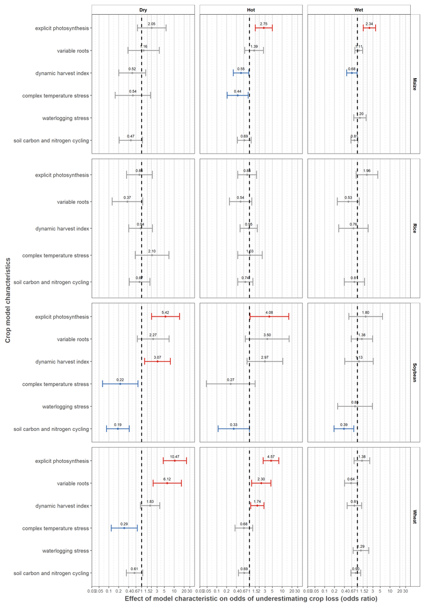

```r
# Prepare data with effect classification and formatting
plot_data <- GLMM_df %>%
  mutate(
    crop = recode(crop,
      "mai" = "Maize",
      "ri1" = "Rice",
      "soy" = "Soybean",
      "wwh" = "Wheat"),
      term = recode(term,
                     "varroots" = "variable roots",
                    "dynamicHI" = "dynamic harvest index",
                    "complexTstress" = "complex temperature stress",
                    "photosynthesis" = "explicit photosynthesis",
                    "waterlogging" = "waterlogging stress",
                    "soilCN" = "soil carbon and nitrogen cycling"),
    or_label = sprintf("%.2f", estimate),
    effect_group = case_when(
      conf.low <= 1 & conf.high >= 1 ~ "No significant effect",  # CI includes 1
      estimate < 1 ~ "Decreases odds of underestimating\nimpact of climatic extremes",
      estimate > 1 ~ "Increases odds of underestimating\nimpact of climatic extremes"
    ),
    label = term  # Only show term on y-axis
  ) %>%
  arrange(desc(estimate)) %>%
  mutate(label = factor(label, levels = rev(unique(label))))  # Reverse y-axis order

# Color palette
effect_colors <- c(
  "Increases odds of underestimating\nimpact of climatic extremes" = "#D73027",  # Red
  "Decreases odds of underestimating\nimpact of climatic extremes" = "#4575B4",  # Blue
  "No significant effect" = "gray60"                                             # Gray
)

# Create the forest plot
forest_plot <- ggplot(plot_data, aes(x = estimate, y = label, color = effect_group)) +
  geom_errorbarh(aes(xmin = conf.low, xmax = conf.high), height = 0.3, size = 1) +
  geom_point(size = 2) +
  geom_vline(xintercept = 1, linetype = "dashed", color = "black", size = 1) +
  geom_text(aes(label = or_label), vjust = -1, size = 3.1, color = "black") +
  scale_color_manual(values = effect_colors, guide = "none") +
  scale_x_log10(
    name = "Effect of model characteristic on odds of underestimating crop loss (odds ratio)",
    breaks = c(0.03, 0.05, 0.1, 0.2, 0.4, 0.67, 1, 1.5, 2, 3, 5, 10, 20, 30), # create log scale
  labels = c("0.03", "0.05", "0.1", "0.2", "0.4", "0.67", "1", "1.5", "2", "3", "5", "10", "20", "30"),
  limits = c(0.03, 30),
    expand = expansion(mult = c(0, 0.05))
  ) +
  facet_grid(crop ~ extreme, scales = "free_y") +  # 4 rows x 3 columns
  labs(y = "Crop model characteristics") +
  theme_Scherer(base_size = 12) +
  theme(
    axis.text.x = element_text(size = 10),
    strip.text = element_text(size = 11, face = "bold"),
    panel.grid.major.y = element_blank()
  )

forest_plot
```

```r
# Save the plot
ggsave(file.path(base_path, "fig5_CharacteristicsExtremes.png"), forest_plot, width = 14, height = nrow(plot_data) * 0.15 + 4, dpi = 300)
```

## Supplementary figure 39 - intercept odds

To really interpret the synthesis plot with odds ratios more thoroughly, one needs to know what the odds of the intercept are to know if the effect has a relevant influence. Imagine the intercept odds to be 1.4 (so 1.4 times more likely to have underestimation than not given a model without any of the 6 characteristics), and the odds ratio to be 0.5 for characteristic A (so 0.5 times more likely to have underestimation given a model that includes characteristic A compared to the intercept). This would mean that the odds of underestimation for a model with characteristic A is 1.4 * 0.5, which is 0.7. So for the intercept, underestimation is dominant, while including A changes the results such that underestimation is not dominant anymore. To get to probabilities instead of odds, one needs to divide the intercept odds with the intercept odds +1.

We create a function to extract the 90% CIs for the intercept odds

```r
# function to extract intercept summary
extract_intercept <- function(GLMM, crop, extreme, conf_level = 0.90) {
  # Extract tidy summary with CI on exponentiated scale (odds)
  tidy_df <- broom.mixed::tidy(GLMM, effects = "fixed", conf.int = TRUE, conf.level = conf_level, exponentiate = TRUE)

  # Filter intercept only
  intercept_df <- tidy_df %>%
    filter(term == "(Intercept)") %>%
    mutate(
      crop = crop,
      extreme = extreme,
      combo = paste(crop, extreme, sep = " | ")
    )
  return(intercept_df)
}
```

We can loop over all GLMMs to extract the intercept CIs and we bind the data into one large dataframe.

```r
all_intercepts <- list()
for (crop in crops) { # Start crops loop
  for (extreme in extremes) { # Start extremes loop

       GLMM <- GLMM_results[[paste(crop, extreme, sep = "_")]]
    intercept_summary <- extract_intercept(GLMM, crop, extreme)
    all_intercepts <- append(all_intercepts, list(intercept_summary))
  }
}
all_intercepts_df <- bind_rows(all_intercepts)
```

Now we can visualize the CIs of the intercept odds in a forest plot

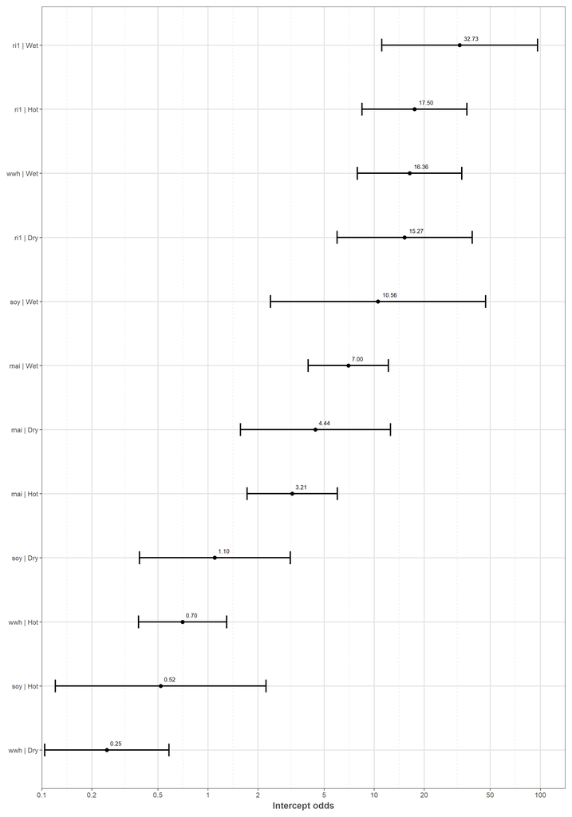

```r
# Sort y-axis by descending odds
all_intercepts_df <- all_intercepts_df %>%
  arrange(estimate) %>%
  mutate(combo = factor(combo, levels = unique(combo)))

plot <- ggplot(all_intercepts_df, aes(x = estimate, y = combo)) +
  geom_point(size = 3) +
  geom_errorbarh(aes(xmin = conf.low, xmax = conf.high), height = 0.2, size = 1.2) +
  geom_text(aes(label = sprintf("%.2f", estimate)), vjust = -1, hjust = -0.3, size = 3.5, color = "black") +
  scale_x_log10(
    name = "Intercept odds",
    breaks = c(0.1, 0.2, 0.5, 1, 2, 5, 10, 20, 50, 100),
    labels = c("0.1", "0.2", "0.5", "1", "2", "5", "10", "20", "50", "100"),
    limits = c(0.1, 100),
    expand = expansion(mult = c(0, 0.05))
  ) +
  labs(y = NULL)

plot
```

```r
ggsave(file.path(base_path, "suppfig39_CharacteristicsExtremes.png"), plot, width = 14, height = nrow(plot_data) * 0.15 + 4, dpi = 300)
```